# Tree Based Methods

# 1 Resources

https://www.rpubs.com/olga_bradford/473175

https://irene.vrbik.ok.ubc.ca/quarto/machine-learning/labs/lab5.html

https://r4ds.github.io/bookclub-islr/tree-based-methods.html

# 2 Tree-based methods

In this chapter, we describe tree-based methods for regression and classification. These involve stratifying or segmenting the predictor space into a number of simple regions. In order to make a prediction for a given observation, we typically use the mean or the mode response value for the training observations in the region to which it belongs. Since the set of splitting rules used to segment the predictor space can be summarized in a tree, these types of approaches are known as decision tree methods. Tree-based methods are simple and useful for interpretation. However, they typically are not competitive with the best supervised learning approaches, such as those seen already, in terms of prediction accuracy. Hence in this chapter we also introduce bagging, random forests, boosting, and Bayesian additive regression trees. Each of these approaches involves producing multiple trees which are then combined to yield a single consensus prediction. We will see that combining a large number of trees can often result in dramatic improvements in prediction accuracy, at the expense of some loss in interpretation.

Let’s look at the Baseball salary data. We are focusing in two variables to predict the Salary: Hits and Years. How could we stratify it?

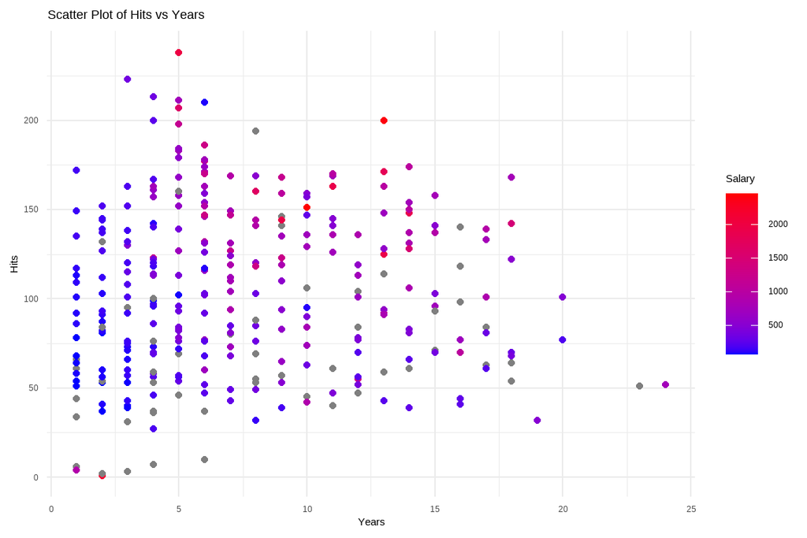

```r
ggplot(Hitters, aes(x = Years, y = Hits, color = Salary)) + geom_point() + scale_color_gradient(low = "blue", high = "red") + labs(title = "Scatter Plot of Hits vs Years", x = "Years", y = "Hits", color = "Salary") + theme_minimal()
```

Visually looking at this we can say that overall, players with less than 5 years are in the lower range of salary and after 5 years it depends based on the Hits. A decision tree is going to try to do that split for us.

The algorithm divides the predictor space (the set of possible values for $X_1,X_2\dots,X_p$) into $J$ distinct and non-overlapping regions $R_1,R_2,\dots,R_j$ For every observation that falls into the region, we make the same prediction, which is simply the mean of the response value for the training observations in $R_j$. To decide on the splits we could think about trying to write the feature space into boxes where the edges of the regions are parallel to the axes.

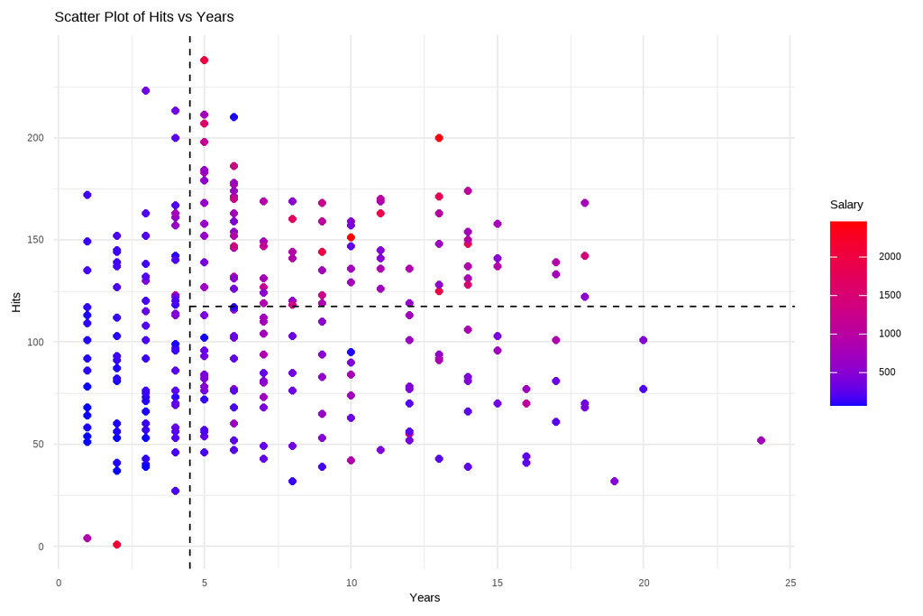

In theory, the regions could have any shape. However, we choose to divide the predictor space into high-dimensional rectangles for simplicity and for ease of interpretation of the resulting predictive model. The goal is to find boxes to minimize the RSS:

$$\sum^J_{j=1}\sum_{i\in R_j}(y_i-\hat y_{Rj})^2$$
where $\hat y_{Rj}$ is the mean response for the training observations within the $jth$ box.

Unfortunately, it is computationally unfeasible to consider every possible partition of the feature space into J boxes, for this reason, we take a *top-down* approach that is known as recursive binary splitting. The approach is top-down because it begins at the top of the tree and then successively splits the predictor space, each split is indicated via two new branches further down on the three. **At each step of the tree-building process, the best split is made at that particular step, rather than looking ahead and picking a split that will lead to a better tree in some future step**. We repeat the process, in each region, looking a the best predictor and the best cut-points in order to split the data further so as to minimize the RSS within each of the resulting regions. The process continues until a stopping criterion is reached, for instance, we may continue until no region contains more than 5 observations.

```r
Hitters<- na.omit(Hitters)
tree.Hitters <- tree(Salary ~ Hits + Years, Hitters)
tree.Hitters <- prune.tree(tree.Hitters, best = 3)
summary(tree.Hitters)
```

```
Regression tree:
snip.tree(tree = tree.Hitters, nodes = c(6L, 2L, 7L))
Number of terminal nodes:  3
Residual mean deviance:  115500 = 30040000 / 260
Distribution of residuals:
   Min. 1st Qu.  Median    Mean 3rd Qu.    Max.
-859.20 -164.90  -74.17    0.00   65.08 1902.00
```

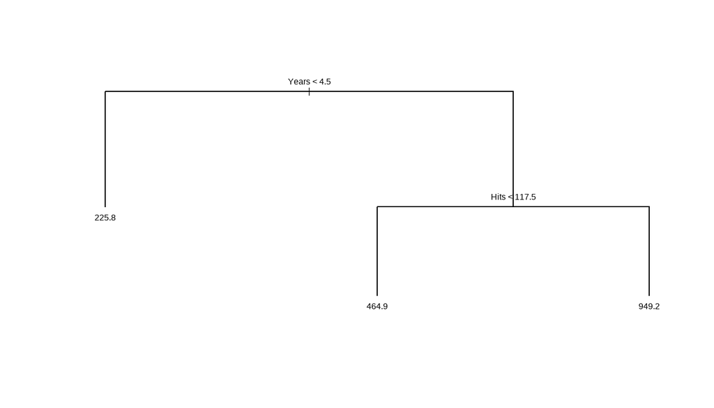

```r
plot(tree.Hitters, pretty=0)
# Add text labels to the plot
text(tree.Hitters, pretty = 0)
```

The values at the end of each node show the mean salary for each bin. The salary is expressed in the dataset in annual salary in thousands of dollars. We can calculate those means manually to confirm:

```r
# Fit the decision tree
tree.Hitters <- tree(Salary ~ Hits + Years, data = Hitters)
tree.Hitters <- prune.tree(tree.Hitters, best = 3)
# Function to extract node means
node_means <- function(tree_model, data) {
  node_indices <- tree_model$where
  node_list <- split(data$Salary, node_indices)
  sapply(node_list, mean)
}

# Calculate the mean salaries for each terminal node
mean_salaries <- node_means(tree.Hitters, Hitters)
mean_salaries
```

```
       2        4        5
225.8315 464.9167 949.1708
```

**Terminology for Trees** In keeping with the tree analogy, the regions at the end are called *terminal nodes* Decision trees are typically drawn upside down in the sense that the leaves are at the bottom of the tree. The points along the tree where the predictor space is split are referred as *internal nodes* In the hitters tree shown above, the two internal nodes are indicated by the ext `years<4.5` and `Hits < 117.5`

**Interpretation of the results** The first division is done over years of experience, this means that the most important factor in determining Salary is years. Given that a player is less experienced, the number of hits that he made in the previous year seems to play little role in his salary. But among players who have been in the major leagues for five or more years, the number of hits made in the previous year does affect the Salary, with players with more Hits having higher salaries. (Note that we have actually limited the number of nodes with the function `prune.tree()`, otherwise it would have shown further divisions). The longer the vertical sections of the diagram the more RSS reduction that split created.

## 2.1 Predictions

We predict the response for a given test observation using the mean of the training observations in the region to which that test observation belongs.

## 2.2 Pruning

If we leave the tree to have as many nodes as possible, it will produce a tree that may produce good predictions on the training set, but it is likely to overfit the data, leading to poor test set performance. A smaller tree with fewer splits might lead to lower variance and better interpretation at the cost of a little bias.

One possible alternative to the process described above is to grow the tree only so long as the decrease in the RSS due to each split exceeds some threshold. This strategy will result in smaller trees, but it is too short sighted: a seemingly worthless split early on in the tree might be followed by a very good split (that is, a split that leads to a large reduction in RSS later on)

A better strategy is to grow a very large tree $T_0$ and then prune it back in order to obtain a subtree. A strategy called *cost complexity pruning* or *weakest link pruning* is used to do this.

We consider a sequence of trees indexed by a non negative tuning parameter $\alpha$. For each value of alpha there corresponds a subtree $T \subset T_0$ such that the expression below is as small as possible:

$$\sum^{|T|}_{m=1}\sum_{i:x_i\epsilon R_m}(y_i-\hat y_{Rm})^2+\alpha|T|$$

where $|T|$ indicates the number of terminal nodes of the tree. $R_m$ is the rectangle or region (the subset of predictor space) corresponding to the mth terminal node, and $\hat y_{Rm}$ is the mean of the training observations in the region. So we want the sum of squares in the region to be as small as possible, but we put a penalty on the number of terminals by adding the $\alpha |T|$. The concept is similar to the *lasso*. The tuning parameter alpha controls a trade-off between the subtree’s complexity and its fit to the training data. We select an optimal value for alpha using cross validation. We then return to the full dataset and obtain the subtree corresponding to that value of alpha.

We are going to do this manually here to show how the model overfits as more splits are added: the training MSE decreases, but the test MSE increases. The cross validation will help us choose the correct number of nodes to use:

Randomly divided the data set in half and built large regression tree on training data and varied α to create subtrees with different numbers of terminal nodes Finally, performed 6-fold cross-validation to estimate the cross-validated MSE of the trees as a function of α

```r
set.seed(123)
trainIndex <- sample(c(TRUE,FALSE), nrow(Hitters), TRUE)

train <- Hitters[trainIndex,]
test <- Hitters[!trainIndex,]

tree_model <- tree(Salary ~ Hits + Years, data = train)

# Perform cross-validation
cv_tree <- cv.tree(tree_model, FUN = prune.tree, K = 6)

# Extract the tree size and corresponding deviance
(tree_sizes <- cv_tree$size)
```

```
[1] 11 10  8  7  6  4  3  2  1
```

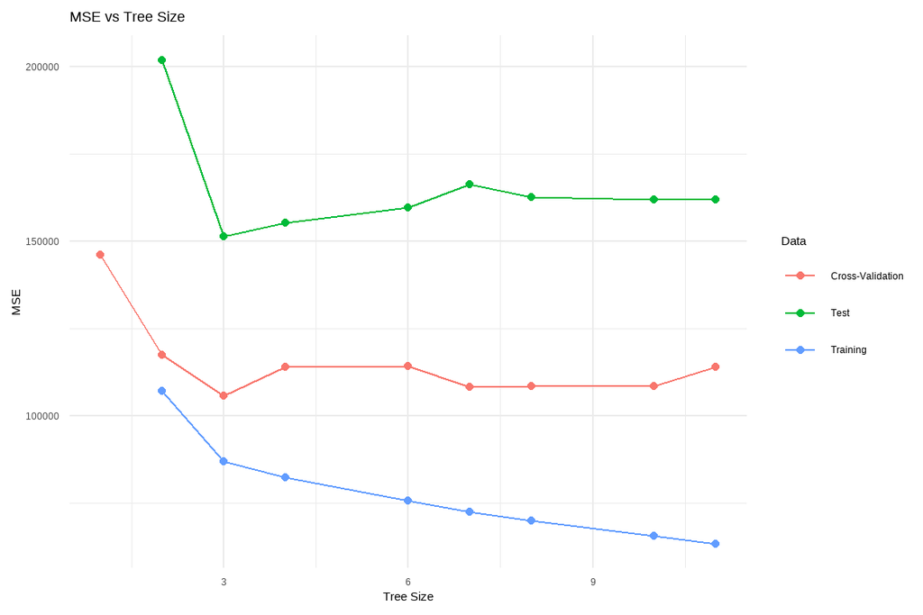

```r
tree_deviances <- cv_tree$dev

# Calculate training and test MSE for each tree size
train_mse_list <- c()
test_mse_list <- c()
for (size in tree_sizes) {
  pruned_tree <- prune.tree(tree_model, best = size)
  # Skip tree sizes that result in a single node
if (nrow(pruned_tree$frame) > 1) {
  #calculate MSE
  train_pred <- predict(pruned_tree, train)
  train_mse <- mean((train_pred - train$Salary)^2)
  test_pred <- predict(pruned_tree, test)
  test_mse <- mean((test_pred - test$Salary)^2)
  }
else {
  train_mse <- NA
  test_mse <- NA }
train_mse_list <- c(train_mse_list, train_mse)
test_mse_list <- c(test_mse_list, test_mse)
}

# Calculate cross-validated MSE (average deviance from cross-validation)
cv_mse <- tree_deviances / length(train$Salary)

results <- data.frame(
  TreeSize = rep(tree_sizes, 3),
  MSE = c(train_mse_list, test_mse_list, cv_mse),
  Data = rep(c("Training", "Test", "Cross-Validation"), each = length(tree_sizes))
)

ggplot(results, aes(x = TreeSize, y = MSE, color = Data)) +
  geom_line() +
  geom_point() +
  labs(title = "MSE vs Tree Size", x = "Tree Size", y = "MSE") +
  theme_minimal()
```

Let’s see how the tree on the hits dataset looks without manual pruning. We are letting the software choose the right number of nodes:

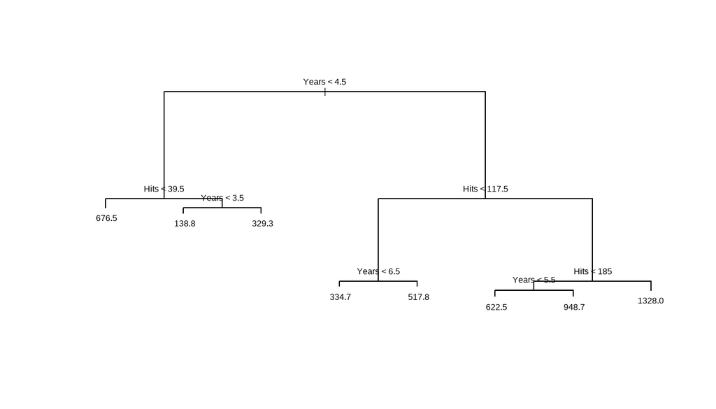

```r
tree.Hitters <- tree(Salary ~ Hits + Years, Hitters)

plot(tree.Hitters, pretty=0)
# Add text labels to the plot
text(tree.Hitters, pretty = 0)
```

The tree function grows a large, unpruned tree. This tree is typically overgrown and will have more terminal nodes than necessary to capture the underlying structure of the data. By default, the tree function will grow the tree until the decrease in deviance (a measure of model fit) is not statistically significant at each split.

Cross-Validation and Pruning: The process we followed to determine the optimal number of terminal nodes involves:

Growing a large tree: This is similar to what the tree function does by default.

Pruning the tree: We use cross-validation to determine the optimal size of the tree that minimizes the mean squared error (MSE). This involves pruning the large tree to a smaller, more optimal size.

```r
cv_tree <- cv.tree(tree_model, FUN = prune.tree, K = 6)

# Determine the tree size with the minimum deviance
optimal_size <- tree_sizes[which.min(tree_deviances)]

# Prune the tree to the optimal size
pruned_tree <- prune.tree(tree_model, best = optimal_size)
summary(pruned_tree)
```

```
Regression tree:
snip.tree(tree = tree_model, nodes = c(2L, 7L, 6L))
Number of terminal nodes:  3
Residual mean deviance:  89150 = 11320000 / 127
Distribution of residuals:
   Min. 1st Qu.  Median    Mean 3rd Qu.    Max.
-759.30 -148.30  -70.32    0.00  111.80 1091.00
```

Fitting Regression trees

Here we fit a regression tree to the `Boston` data set. First, we create a training set, and fit the tree to the training data.

```r
set.seed(1)
train <- sample(1:nrow(Boston), nrow(Boston) / 2)
tree.boston <- tree(medv ~ ., Boston, subset = train)
summary(tree.boston)
```

```
Regression tree:
tree(formula = medv ~ ., data = Boston, subset = train)
Variables actually used in tree construction:
[1] "rm"    "lstat" "crim"  "age"
Number of terminal nodes:  7
Residual mean deviance:  10.38 = 2555 / 246
Distribution of residuals:
    Min.  1st Qu.   Median     Mean  3rd Qu.     Max.
-10.1800  -1.7770  -0.1775   0.0000   1.9230  16.5800
```

Notice that the output of `summary()` indicates that only four of the variables have been used in constructing the tree. In the context of a regression tree, the **deviance** is simply the sum of squared errors for the tree. We now plot the tree.

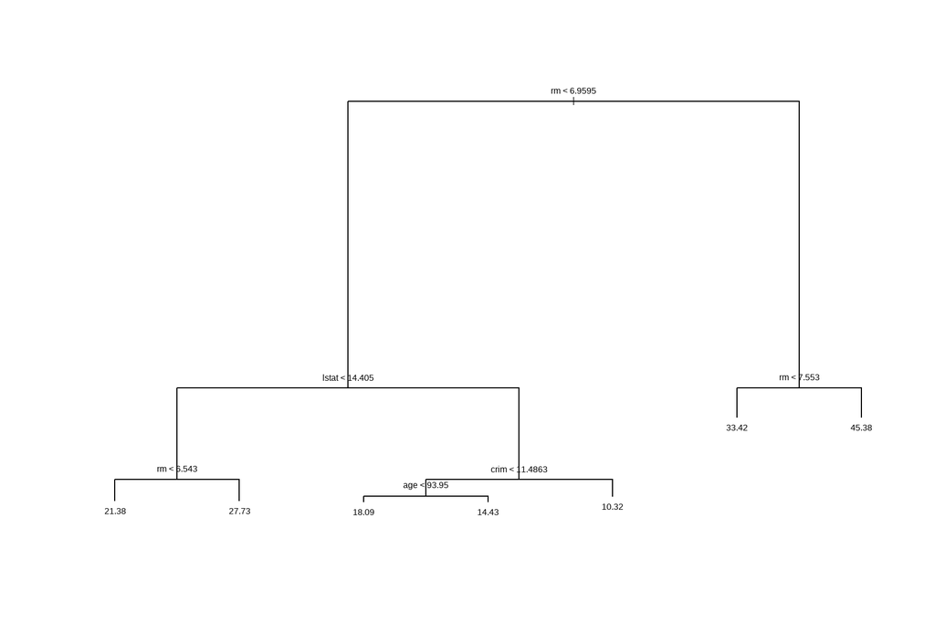

```r
plot(tree.boston)
text(tree.boston, pretty = 0)
```

The variable `lstat` measures the percentage of individuals with {lower socioeconomic status}, while the variable `rm` corresponds to the average number of rooms. The tree indicates that larger values of `rm`, or lower values of `lstat`, correspond to more expensive houses. For example, the tree predicts a median house price of $45{,}400$ for homes in census tracts in which `rm >= 7.553`.

It is worth noting that we could have fit a much bigger tree, by passing `control = tree.control(nobs = length(train), mindev = 0)` into the `tree()` function.

Now we use the `cv.tree()` function to see whether pruning the tree will improve performance.

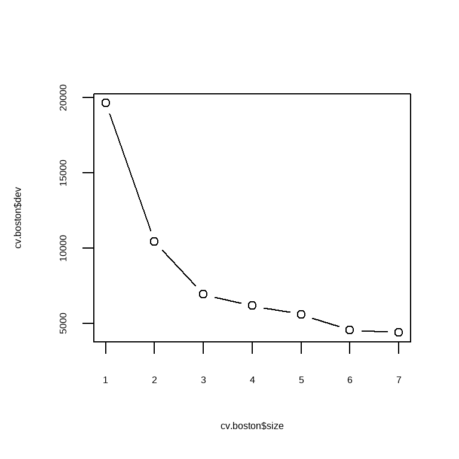

```r
cv.boston <- cv.tree(tree.boston)
plot(cv.boston$size, cv.boston$dev, type = "b")
```

In this case, the most complex tree under consideration is selected by cross-validation. However, if we wish to prune the tree, we could do so as follows, using the `prune.tree()` function:

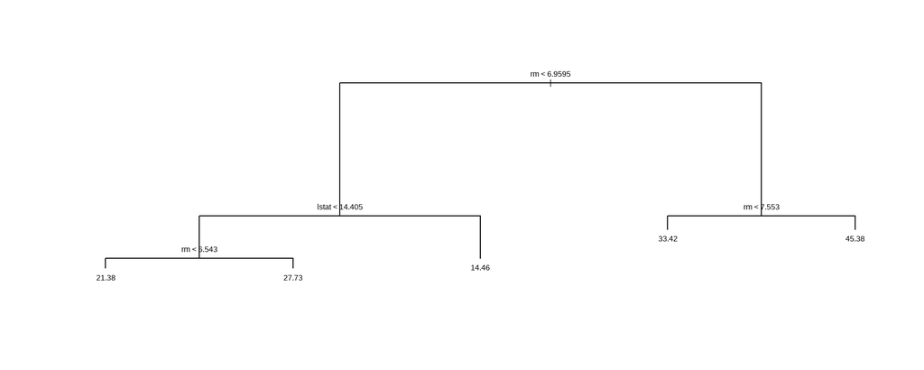

```r
prune.boston <- prune.tree(tree.boston, best = 5)
plot(prune.boston)
text(prune.boston, pretty = 0)
```

In keeping with the cross-validation results, we use the unpruned tree to make predictions on the test set.

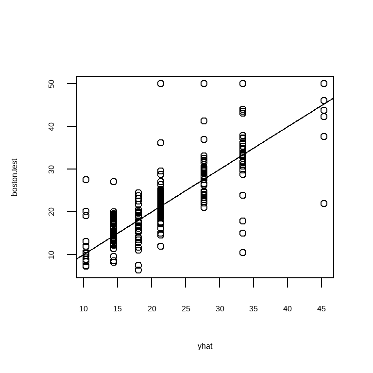

```r
yhat <- predict(tree.boston, newdata = Boston[-train, ])
boston.test <- Boston[-train, "medv"]
plot(yhat, boston.test)
abline(0, 1)
```

```r
mean((yhat - boston.test)^2)
```

```
[1] 35.28688
```

In other words, the test set MSE associated with the regression tree is $35.29$. The square root of the MSE is therefore around $5.941$, indicating that this model leads to test predictions that are (on average) within approximately $5{,}941$ of the true median home value for the census tract.

Regression trees using rpart

We will build a Regression Tree to predict the median house value (medv) in the Boston dataset based on various features such as crime rate, number of rooms, and distance to employment centers.

We will use the library `rpart`

```r
#split 70% of the data for training
train_index <- sample(1:nrow(Boston), 0.7*nrow(Boston))
train_boston <- Boston[train_index,]
test_boston <- Boston[-train_index,]

# Train a Regression Tree
rt_model <- rpart(medv ~ ., data = train_boston, method = "anova")
rt_model
```

```
n= 354

node), split, n, deviance, yval
      * denotes terminal node

 1) root 354 30392.2700 22.78164
   2) rm< 6.92 299 11489.1900 20.03612
     4) lstat>=14.405 118  2454.7150 15.15169
       8) nox>=0.603 70   969.6979 12.92143
        16) crim>=11.343 24   117.3763  9.36250 *
        17) crim< 11.343 46   389.7383 14.77826 *
       9) nox< 0.603 48   629.0592 18.40417 *
     5) lstat< 14.405 181  4383.9540 23.22044
      10) rm< 6.543 139  2917.2830 21.95540
        20) dis>=1.6156 132  1161.2110 21.53788 *
        21) dis< 1.6156 7  1299.1540 29.82857 *
      11) rm>=6.543 42   508.0279 27.40714 *
   3) rm>=6.92 55  4396.6570 37.70727
     6) rm< 7.433 34  1254.4960 32.72059
      12) lstat>=8.355 7   303.9600 26.30000 *
      13) lstat< 8.355 27   587.1541 34.38519 *
     7) rm>=7.433 21   927.8124 45.78095 *
```

we can visualize the trained regression tree:

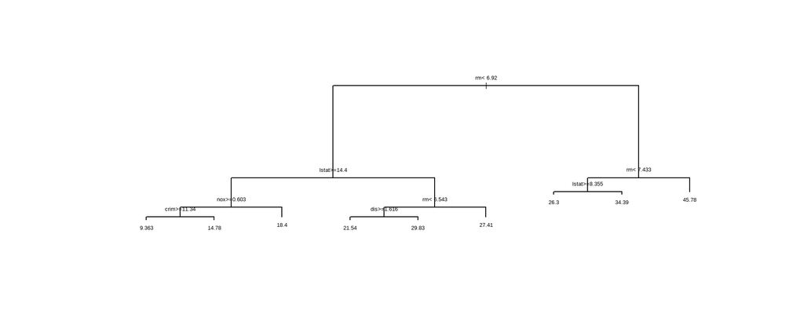

```r
# Plot the regression tree
plot(rt_model, margin = 0.1)  # decrease margin for readability
text(rt_model, cex=0.8)       # decrease font size for readability
```

Note that the returned tree in rt_model has already been pruned by default. If you want to see what was going on under the hood, we can force `rpart()` to grow the “bushy” tree by setting the cost complexity $\alpha$ =0 (called cp)

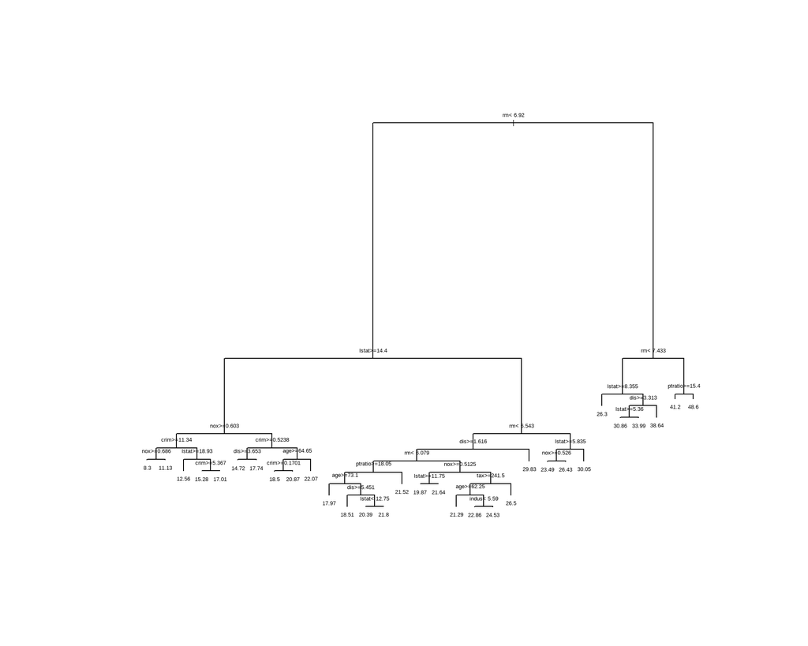

```r
bushy_tree <- rpart(
    formula = medv ~ .,
    data    = train_boston,
    method  = "anova",
    control = list(cp = 0) # set the cost complexity parameter to 0
)
plot(bushy_tree, margin = 0.1)  # decrease margin for readability
text(bushy_tree, cex=0.8)       # decrease font size for readability
```

To see if pruning is needed let’s investigate the cross-validated error as a function of the complexity parameter

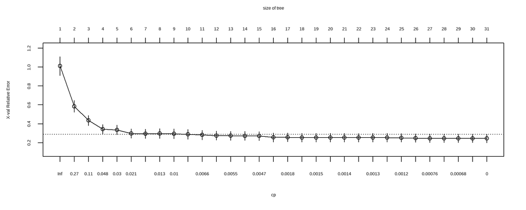

```r
# Plot the cross-validation results
plotcp(bushy_tree)
```

Here’s how to interpret the plot:

```r
bushy_tree$cptable
```

```
             CP nsplit rel error    xerror       xstd
1  0.4773063463      0 1.0000000 1.0095307 0.09977729
2  0.1530165655      1 0.5226937 0.5847799 0.06238429
3  0.0728589564      2 0.3696771 0.4351669 0.05392774
4  0.0315423308      3 0.2968181 0.3434853 0.04935675
5  0.0281636620      4 0.2652758 0.3359006 0.05034302
6  0.0152204273      5 0.2371121 0.2966194 0.04955162
7  0.0150340383      6 0.2218917 0.2941126 0.04994947
8  0.0119563793      7 0.2068577 0.2968220 0.05266061
9  0.0089230707      8 0.1949013 0.2943669 0.05263854
10 0.0065782220      9 0.1859782 0.2884455 0.05138245
11 0.0065592854     10 0.1794000 0.2823226 0.05021831
12 0.0056365460     11 0.1728407 0.2753692 0.04762677
13 0.0054386848     12 0.1672042 0.2740205 0.04743106
14 0.0048069868     13 0.1617655 0.2723186 0.04746668
```

[output cut: 17 more lines]

To prune using the 1-SE rule:

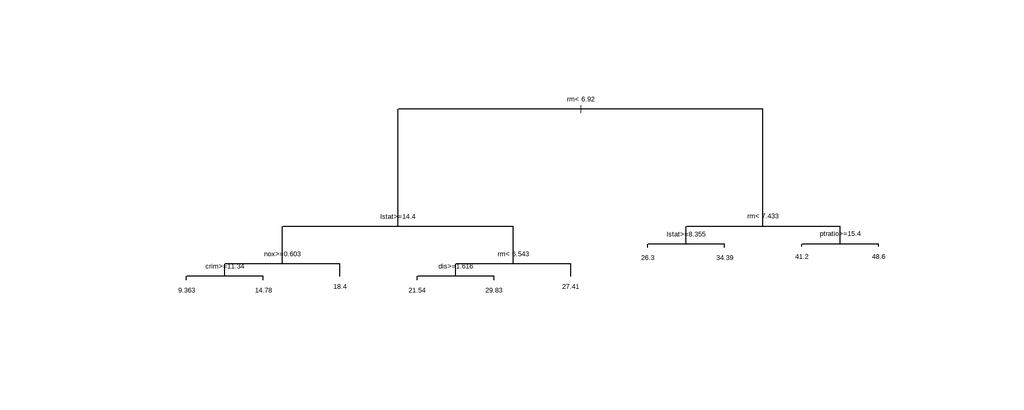

```r
# Step 1: Find the minimum cross-validated error and its corresponding standard error
min_xerror <- min(bushy_tree$cptable[, "xerror"])
min_xstd <- bushy_tree$cptable[which.min(bushy_tree$cptable[, "xerror"]), "xstd"]

# Step 2: Calculate the threshold for the 1-SE rule
threshold <- min_xerror + min_xstd

# Step 3: Find the smallest tree where the xerror is within the threshold
# We use which() to find all indices where xerror is within the threshold
# Then we choose the smallest cp that satisfies this condition
optimal_cp_1se <- bushy_tree$cptable[which(bushy_tree$cptable[, "xerror"] <= threshold)[1], "CP"]

# Step 4: Prune the tree using the optimal cp from the 1-SE rule
pruned_model <- prune(bushy_tree, cp = optimal_cp_1se)

# Step 5: Plot the pruned tree
plot(pruned_model, margin = 0.1)
text(pruned_model, cex = 0.8)
```

**Evaluating the Regression Tree** Going back to the rt_model, we evaluate the regression tree’s performance by predicting on the test set and calculating metrics such as Mean Squared Error (MSE) and R-squared.

```r
# Predict the median house value on the test data
predictions_reg <- predict(rt_model, newdata = test_boston)

# Calculate Mean Squared Error
mse <- mean((predictions_reg - test_boston$medv)^2)
mse
```

```
[1] 18.39567
```

# 3 Classification Trees

Very similar to regression tree, except that it is used to predict a qualitative response rather than a quantitative one, but the mechanism is very similar. For a classification tree, we predict that each observation belongs to the most commonly occurring class of training observations in the region where it belongs.

Just as in the regression setting, we use recursive binary splitting to grow a classification tree. In the classification setting, RSS cannot be used as a criterion for making binary splits. A natural alternative to RSS is the *classification error rate* this is simply the fraction of the training observations in that region that do not belong to the most common class. However, classification error is not sufficiently sensitive for tree-growing, and in practice two other measures are preferable.

## 3.1 Gini index and Deviance

In decision tree algorithms, the *Gini Index* is used as a criterion to measure the purity or impurity of a split in the dataset. The goal is to create nodes that contain observations of mostly one class, leading to better classification accuracy. The Gini index is defined by

$$G = \sum^K_{k=1} \hat p_{mk}(1-\hat p_{mk})
\tag{1}$$

K is the number of classes

the binomial variance formula is:
$$var(X)=n \times p \times (1-p)
\tag{2}$$

so this is a measure of the variability of that region.

If the Gini index is really small, that means that one class is favored and all the rest are really small. If the region is pure, the Gini will be 0.

Let’s look at an example with the Heart data. These data have a binary response called HD. Yes indicates presence of heart disease and No means no heart disease. There are 13 predictors.

The unpruned tree looks like this:

```r
heart<- kmed::heart
heart$hd <- case_when(heart$class == 0 ~"No",
                      TRUE ~ "Yes")
heart_tree <- heart %>%
  mutate_if(is.character, as.factor)

set.seed(417)
index <- sample(nrow(heart), size = nrow(heart)*0.80)
heart_train_tree <- heart_tree[index,] #take 80%
heart_test_tree <- heart_tree[-index,] #take 20%

tree.heart <- tree(hd ~ . -class, data=heart_train_tree)
summary(tree.heart)
```

```
Classification tree:
tree(formula = hd ~ . - class, data = heart_train_tree)
Variables actually used in tree construction:
[1] "thal"     "ca"       "age"      "trestbps" "cp"       "exang"    "sex"
[8] "oldpeak"  "chol"
Number of terminal nodes:  20
Residual mean deviance:  0.41 = 88.97 / 217
Misclassification error rate: 0.08017 = 19 / 237
```

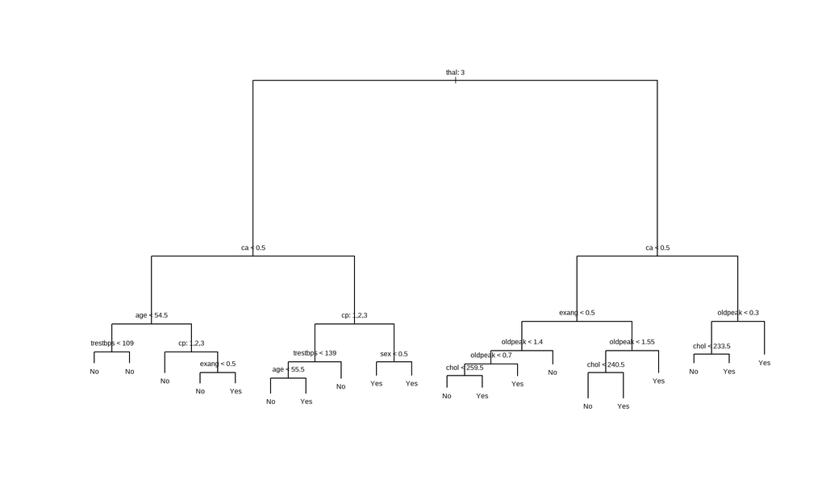

```r
plot(tree.heart)
text(tree.heart, pretty=0)
```

Let’s do cross-validation now:

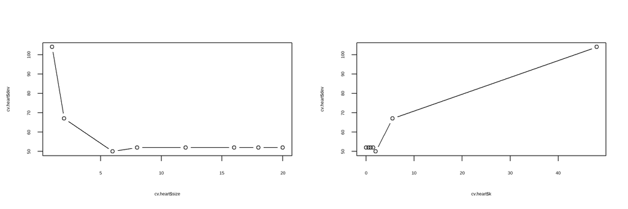

```r
set.seed(7)
cv.heart <- cv.tree(tree.heart, FUN = prune.misclass)

par(mfrow = c(1, 2))
plot(cv.heart$size, cv.heart$dev, type = "b")
plot(cv.heart$k, cv.heart$dev, type = "b")
```

cross validation indicates that the best number of nodes is 6

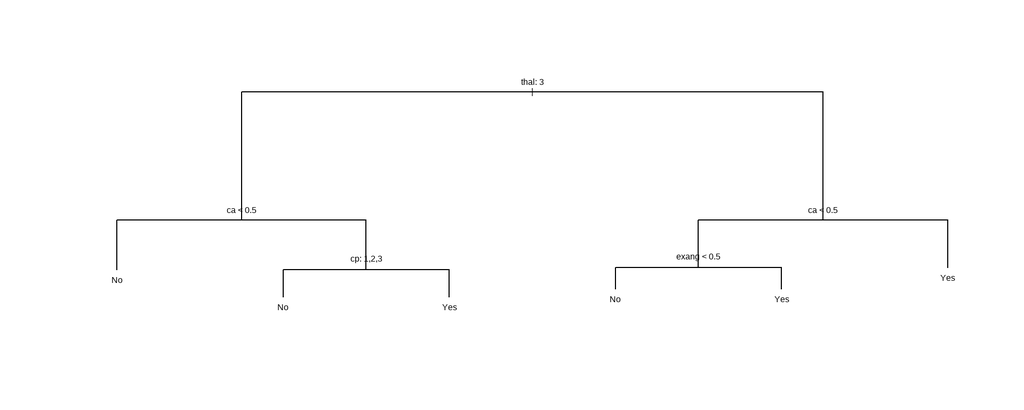

```r
prune.heart <- prune.misclass(tree.heart, best = 6)
plot(prune.heart)
text(prune.heart, pretty = 0)
```

Advantages and disadvantages of Trees

Pros: - Trees are very easy to explain to people. - Some people believe that decision trees more closely mirror human decision-making than do regression and classification approaches. - Trees can be displayed graphically. - Trees can easily handle qualitative predictors without the need to create dummy variables.

Cons: - Unfortunately, trees generally do not have the same level of predictive accuracy as some of the other regression and classification approaches seen already.

Fitting classification trees

We will have a look at the `Carseats` data using the `tree` package

We want a response variable that is qualitative so we are going to turn sales into a binary response. Let’s see what value can be appropriate:

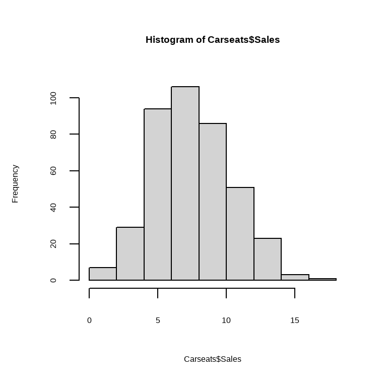

```r
hist(Carseats$Sales)
```

We create a binary response variable ‘high’ for high sales:`ifelse()` function creates a variable, called `High`, which takes on a value of `Yes` if the `Sales` variable exceeds $8$,and takes on a value of `No` otherwise.

```r
Carseats$High <- factor(ifelse(Carseats$Sales <= 8, "No", "Yes"))
```

**Correlation Analysis** Correlation heatmap (Pearson)

```r
# convert factor features to numeric for correlation analysis
carseats_num <- Carseats %>%
     mutate(High = ifelse(High == "No", 0 , 1),
            Urban = ifelse(Urban == "No", 0, 1),
            US = ifelse(US == "No", 0, 1),
            ShelveLoc = case_when(
                 ShelveLoc == 'Bad' ~ 1,
                 ShelveLoc == "Medium" ~ 2,
                 TRUE ~ 3
            ))

carseats_num
```

[output not shown]

[output cut: 787 more lines]

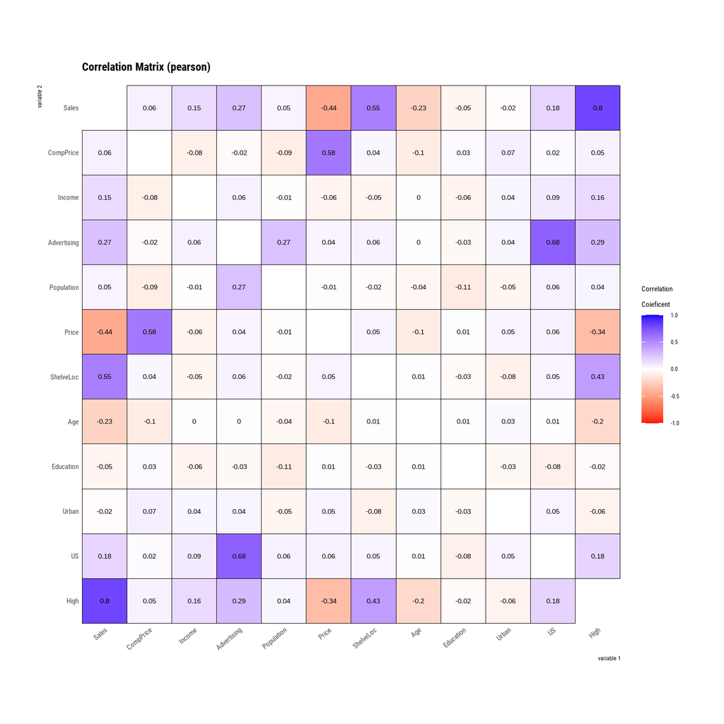

```r
carseats_num %>%
  dlookr::correlate() %>%
  plot()
```

We now use the `tree()` function to fit a classification tree in order to predict `High` using all variables but `Sales`. The syntax of the `tree()` function is quite similar to that of the `lm()` function.

```r
tree.carseats <- tree(High ~ . - Sales, Carseats)
```

The `summary()` function lists the variables that are used as internal nodes in the tree, the number of terminal nodes, and the (training) error rate.

```r
summary(tree.carseats)
```

```
Classification tree:
tree(formula = High ~ . - Sales, data = Carseats)
Variables actually used in tree construction:
[1] "ShelveLoc"   "Price"       "Income"      "CompPrice"   "Population"
[6] "Advertising" "Age"         "US"
Number of terminal nodes:  27
Residual mean deviance:  0.4575 = 170.7 / 373
Misclassification error rate: 0.09 = 36 / 400
```

We see that the training error rate is $9\%$. For classification trees, the deviance reported in the output of `summary()` is given by

$$-2 \sum_m \sum_k n_{mk} \log \hat{p}_{mk},$$

where $n_{mk}$ is the number of observations in the $m$th terminal node that belong to the $k$th class. This is closely related to the entropy. A small deviance indicates a tree that provides a good fit to the (training) data. The *residual mean deviance* reported is simply the deviance divided by $n-|{T}_0|$, which in this case is $400-27=373$.

One of the most attractive properties of trees is that they can be graphically displayed. We use the `plot()` function to display the tree structure, and the `text()` function to display the node labels. The argument `pretty = 0` instructs `R` to include the category names for any qualitative predictors, rather than simply displaying a letter for each category.

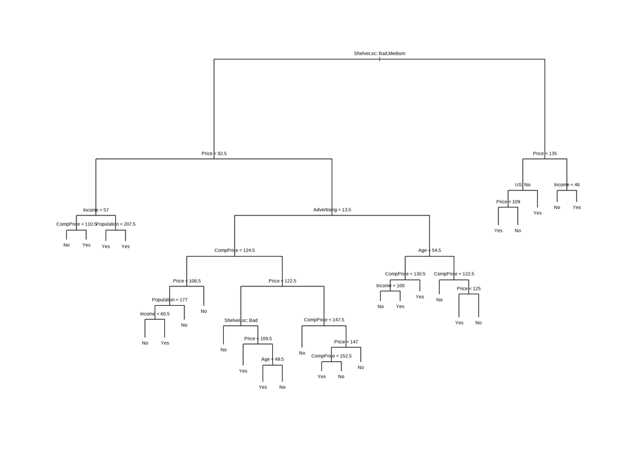

```r
plot(tree.carseats)
text(tree.carseats, pretty = 0)
```

The most important indicator of `Sales` appears to be shelving location, since the first branch differentiates `Good` locations from `Bad` and `Medium` locations.

If we just type the name of the tree object, `R` prints output corresponding to each branch of the tree. `R` displays the split criterion (e.g. `Price < 92.5`), the number of observations in that branch, the deviance, the overall prediction for the branch (`Yes` or `No`), and the fraction of observations in that branch that take on values of `Yes` and `No`. Branches that lead to terminal nodes are indicated using asterisks.

```r
tree.carseats
```

```
node), split, n, deviance, yval, (yprob)
      * denotes terminal node

  1) root 400 541.500 No ( 0.59000 0.41000 )
    2) ShelveLoc: Bad,Medium 315 390.600 No ( 0.68889 0.31111 )
      4) Price < 92.5 46  56.530 Yes ( 0.30435 0.69565 )
        8) Income < 57 10  12.220 No ( 0.70000 0.30000 )
         16) CompPrice < 110.5 5   0.000 No ( 1.00000 0.00000 ) *
         17) CompPrice > 110.5 5   6.730 Yes ( 0.40000 0.60000 ) *
        9) Income > 57 36  35.470 Yes ( 0.19444 0.80556 )
         18) Population < 207.5 16  21.170 Yes ( 0.37500 0.62500 ) *
         19) Population > 207.5 20   7.941 Yes ( 0.05000 0.95000 ) *
      5) Price > 92.5 269 299.800 No ( 0.75465 0.24535 )
       10) Advertising < 13.5 224 213.200 No ( 0.81696 0.18304 )
         20) CompPrice < 124.5 96  44.890 No ( 0.93750 0.06250 )
           40) Price < 106.5 38  33.150 No ( 0.84211 0.15789 )
             80) Population < 177 12  16.300 No ( 0.58333 0.41667 )
              160) Income < 60.5 6   0.000 No ( 1.00000 0.00000 ) *
              161) Income > 60.5 6   5.407 Yes ( 0.16667 0.83333 ) *
             81) Population > 177 26   8.477 No ( 0.96154 0.03846 ) *
           41) Price > 106.5 58   0.000 No ( 1.00000 0.00000 ) *
         21) CompPrice > 124.5 128 150.200 No ( 0.72656 0.27344 )
           42) Price < 122.5 51  70.680 Yes ( 0.49020 0.50980 )
             84) ShelveLoc: Bad 11   6.702 No ( 0.90909 0.09091 ) *
             85) ShelveLoc: Medium 40  52.930 Yes ( 0.37500 0.62500 )
              170) Price < 109.5 16   7.481 Yes ( 0.06250 0.93750 ) *
              171) Price > 109.5 24  32.600 No ( 0.58333 0.41667 )
                342) Age < 49.5 13  16.050 Yes ( 0.30769 0.69231 ) *
                343) Age > 49.5 11   6.702 No ( 0.90909 0.09091 ) *
           43) Price > 122.5 77  55.540 No ( 0.88312 0.11688 )
             86) CompPrice < 147.5 58  17.400 No ( 0.96552 0.03448 ) *
             87) CompPrice > 147.5 19  25.010 No ( 0.63158 0.36842 )
              174) Price < 147 12  16.300 Yes ( 0.41667 0.58333 )
                348) CompPrice < 152.5 7   5.742 Yes ( 0.14286 0.85714 ) *
                349) CompPrice > 152.5 5   5.004 No ( 0.80000 0.20000 ) *
              175) Price > 147 7   0.000 No ( 1.00000 0.00000 ) *
       11) Advertising > 13.5 45  61.830 Yes ( 0.44444 0.55556 )
         22) Age < 54.5 25  25.020 Yes ( 0.20000 0.80000 )
           44) CompPrice < 130.5 14  18.250 Yes ( 0.35714 0.64286 )
             88) Income < 100 9  12.370 No ( 0.55556 0.44444 ) *
             89) Income > 100 5   0.000 Yes ( 0.00000 1.00000 ) *
           45) CompPrice > 130.5 11   0.000 Yes ( 0.00000 1.00000 ) *
         23) Age > 54.5 20  22.490 No ( 0.75000 0.25000 )
           46) CompPrice < 122.5 10   0.000 No ( 1.00000 0.00000 ) *
           47) CompPrice > 122.5 10  13.860 No ( 0.50000 0.50000 )
             94) Price < 125 5   0.000 Yes ( 0.00000 1.00000 ) *
             95) Price > 125 5   0.000 No ( 1.00000 0.00000 ) *
    3) ShelveLoc: Good 85  90.330 Yes ( 0.22353 0.77647 )
      6) Price < 135 68  49.260 Yes ( 0.11765 0.88235 )
       12) US: No 17  22.070 Yes ( 0.35294 0.64706 )
         24) Price < 109 8   0.000 Yes ( 0.00000 1.00000 ) *
         25) Price > 109 9  11.460 No ( 0.66667 0.33333 ) *
       13) US: Yes 51  16.880 Yes ( 0.03922 0.96078 ) *
      7) Price > 135 17  22.070 No ( 0.64706 0.35294 )
       14) Income < 46 6   0.000 No ( 1.00000 0.00000 ) *
       15) Income > 46 11  15.160 Yes ( 0.45455 0.54545 ) *
```

In order to properly evaluate the performance of a classification tree on these data, we must estimate the test error rather than simply computing the training error. We split the observations into a training set and a test set, build the tree using the training set, and evaluate its performance on the test data. The `predict()` function can be used for this purpose. In the case of a classification tree, the argument `type = "class"` instructs `R` to return the actual class prediction. This approach leads to correct predictions for around $77 \%$ of the locations in the test data set.

```r
set.seed(2)
train <- sample(1:nrow(Carseats), 200)
Carseats.test <- Carseats[-train, ]

tree.carseats <- tree(High ~ . - Sales, Carseats,
    subset = train)

tree.pred <- predict(tree.carseats, Carseats.test,
    type = "class")
table(tree.pred, Carseats.test$High)
```

```
tree.pred  No Yes
      No  104  33
      Yes  13  50
```

```r
(104 + 50) / 200
```

```
[1] 0.77
```

(If you re-run the `predict()` function then you might get slightly different results, due to “ties”: for instance, this can happen when the training observations corresponding to a terminal node are evenly split between `Yes` and `No` response values.)

Next, we consider whether pruning the tree might lead to improved results. The function `cv.tree()` performs cross-validation in order to determine the optimal level of tree complexity; cost complexity pruning is used in order to select a sequence of trees for consideration.

We use the argument `FUN = prune.misclass` in order to indicate that we want the classification error rate to guide the cross-validation and pruning process, rather than the default for the `cv.tree()` function, which is deviance.

The `cv.tree()` function reports the number of terminal nodes of each tree considered (`size`) as well as the corresponding *error rate* and the value of the cost-complexity parameter used (`k`, which corresponds to $\alpha$).

```r
set.seed(7)
cv.carseats <- cv.tree(tree.carseats, FUN = prune.misclass)
names(cv.carseats)
```

```
[1] "size"   "dev"    "k"      "method"
```

```r
cv.carseats
```

```
$size
[1] 21 19 14  9  8  5  3  2  1

$dev
[1] 75 75 75 74 82 83 83 85 82

$k
[1] -Inf  0.0  1.0  1.4  2.0  3.0  4.0  9.0 18.0

$method
[1] "misclass"

attr(,"class")
[1] "prune"         "tree.sequence"
```

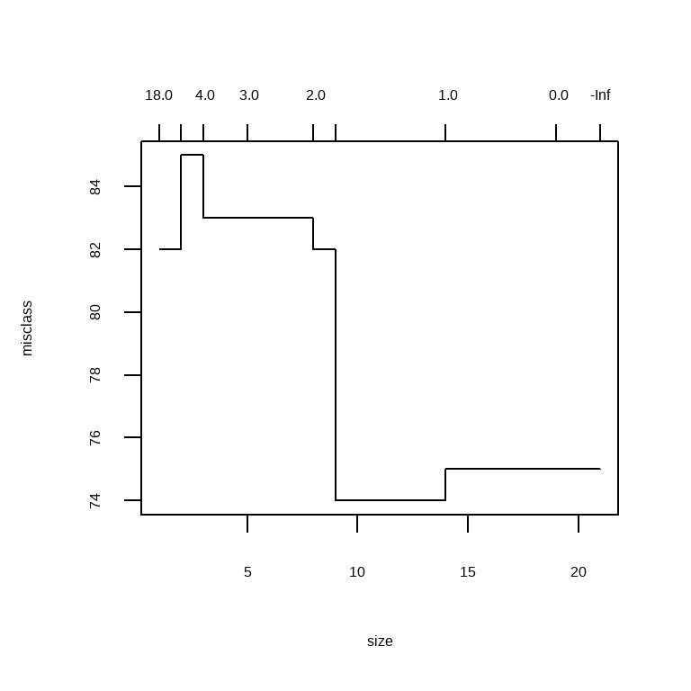

```r
plot(cv.carseats)
```

Despite its name, `dev` corresponds to the number of cross-validation errors. The tree with 9 terminal nodes results in only 74 cross-validation errors. We plot the error rate as a function of both `size` and `k`.

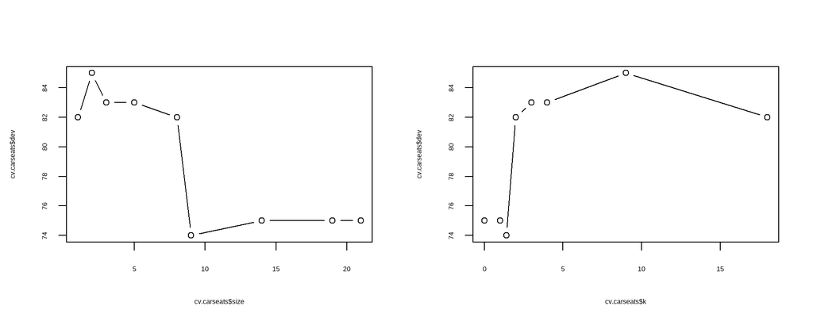

```r
par(mfrow = c(1, 2))
plot(cv.carseats$size, cv.carseats$dev, type = "b")
plot(cv.carseats$k, cv.carseats$dev, type = "b")
```

We now apply the `prune.misclass()` function in order to prune the tree to obtain the nine-node tree.

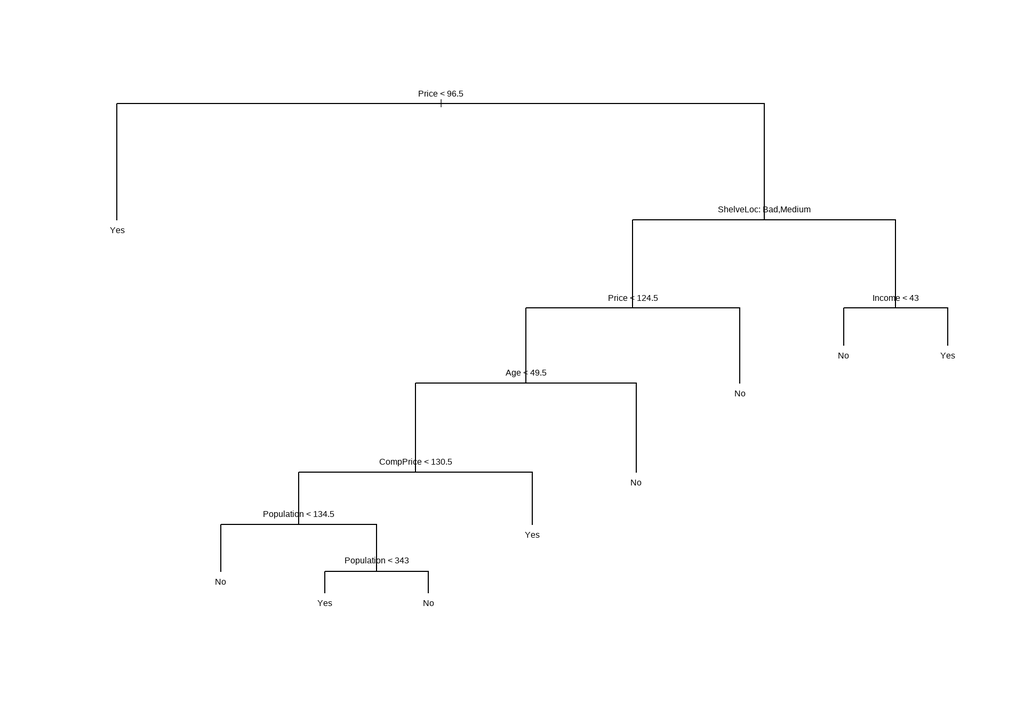

```r
prune.carseats <- prune.misclass(tree.carseats, best = 9)
plot(prune.carseats)
text(prune.carseats, pretty = 0)
```

How well does this pruned tree perform on the test data set? Once again, we apply the `predict()` function.

```r
tree.pred <- predict(prune.carseats, Carseats.test,
    type = "class")
table(tree.pred, Carseats.test$High)
```

```
tree.pred No Yes
      No  97  25
      Yes 20  58
```

```r
(97 + 58) / 200
```

```
[1] 0.775
```

Now $77.5 \%$ of the test observations are correctly classified, so not only has the pruning process produced a more interpretable tree, but it has also slightly improved the classification accuracy.

If we increase the value of `best`, we obtain a larger pruned tree with lower classification accuracy:

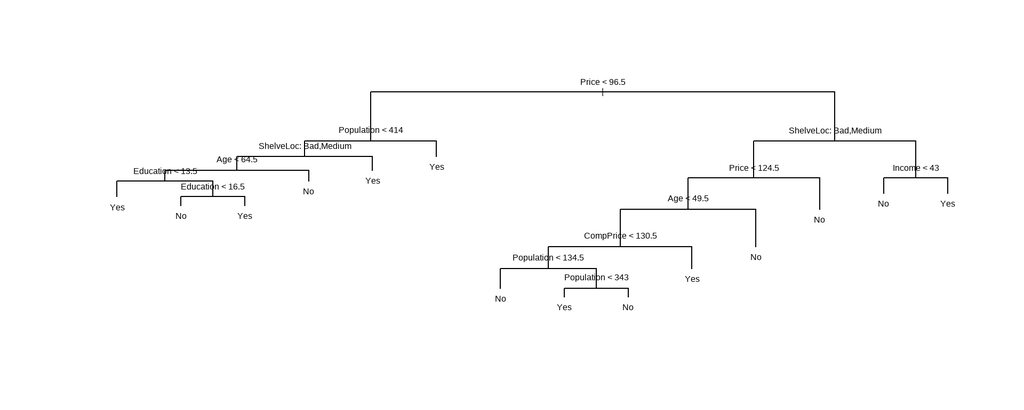

```r
prune.carseats <- prune.misclass(tree.carseats, best = 14)
plot(prune.carseats)
text(prune.carseats, pretty = 0)
```

```r
tree.pred <- predict(prune.carseats, Carseats.test,
    type = "class")

table(tree.pred, Carseats.test$High)
```

```
tree.pred  No Yes
      No  102  31
      Yes  15  52
```

```r
(102 + 52) / 200
```

```
[1] 0.77
```

Classification using rpart

Now we are going to use a different library `rpart` to create classification trees. We will use the `Iris` dataset.

**Data splitting**

```r
set.seed(800)
trainIndex <- sample(1:nrow(iris), 0.7 * nrow(iris))
trainData <- iris[trainIndex, ]
testData <- iris[-trainIndex,]
```

We will build a Classification Tree to classify the species of iris flowers based on their sepal and petal measurements.

```r
# Train a Classification Tree
ct_model <- rpart(Species ~., data = trainData, method = "class")
ct_model
```

```
n= 105

node), split, n, loss, yval, (yprob)
      * denotes terminal node

1) root 105 67 virginica (0.3238095 0.3142857 0.3619048)
  2) Petal.Length< 2.45 34  0 setosa (1.0000000 0.0000000 0.0000000) *
  3) Petal.Length>=2.45 71 33 virginica (0.0000000 0.4647887 0.5352113)
    6) Petal.Width< 1.75 37  4 versicolor (0.0000000 0.8918919 0.1081081) *
    7) Petal.Width>=1.75 34  0 virginica (0.0000000 0.0000000 1.0000000) *
```

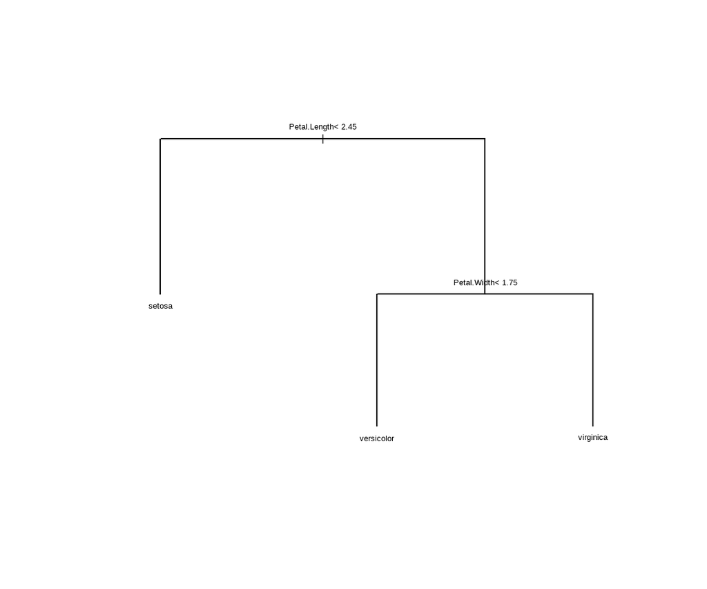

```r
plot(ct_model, margin = 0.1)  # Increase the margin parameter for more space
text(ct_model,  cex = 0.8)
```

Predictions on the test dataset:

```r
# Predict the species on the test data
predictions <- predict(ct_model, newdata = testData, type = "class")

# Evaluate the model with a confusion matrix
conf_matrix <- caret::confusionMatrix(predictions, testData$Species)
print(conf_matrix)
```

```
Confusion Matrix and Statistics

            Reference
Prediction   setosa versicolor virginica
  setosa         16          0         0
  versicolor      0         16         1
  virginica       0          1        11

Overall Statistics

               Accuracy : 0.9556
                 95% CI : (0.8485, 0.9946)
    No Information Rate : 0.3778
    P-Value [Acc > NIR] : 0.000000000000000261

                  Kappa : 0.9326

 Mcnemar's Test P-Value : NA

Statistics by Class:

                     Class: setosa Class: versicolor Class: virginica
Sensitivity                 1.0000            0.9412           0.9167
Specificity                 1.0000            0.9643           0.9697
Pos Pred Value              1.0000            0.9412           0.9167
Neg Pred Value              1.0000            0.9643           0.9697
Prevalence                  0.3556            0.3778           0.2667
Detection Rate              0.3556            0.3556           0.2444
Detection Prevalence        0.3556            0.3778           0.2667
Balanced Accuracy           1.0000            0.9527           0.9432
```

In addition to providing the confusion matrix, the `confusionMatrix()` function provides some associated statistics; interpreting the results of a confusion matrix . We can see all these per class using:

```r
stats_by_class <- conf_matrix$byClass
round(stats_by_class, 3) # round to read easier
```

```
                  Sensitivity Specificity Pos Pred Value Neg Pred Value
Class: setosa           1.000       1.000          1.000          1.000
Class: versicolor       0.941       0.964          0.941          0.964
Class: virginica        0.917       0.970          0.917          0.970
                  Precision Recall    F1 Prevalence Detection Rate
Class: setosa         1.000  1.000 1.000      0.356          0.356
Class: versicolor     0.941  0.941 0.941      0.378          0.356
Class: virginica      0.917  0.917 0.917      0.267          0.244
                  Detection Prevalence Balanced Accuracy
Class: setosa                    0.356             1.000
Class: versicolor                0.378             0.953
Class: virginica                 0.267             0.943
```

In a multi-class classification problem, there is a separate metric for each class because we treat each class as the “positive” class while considering all other classes as “negative”. This approach provides a detailed evaluation of the model’s performance for each individual class. Example, calculating precision for versicolor: Precision, also known as the Positive Predictive Value (PPV) is calculated as:
$$Precision = \frac{True \ Positives}{True\ Positives+ False\ Positives}$$
In our case

```r
conf_matrix$table
```

```
            Reference
Prediction   setosa versicolor virginica
  setosa         16          0         0
  versicolor      0         16         1
  virginica       0          1        11
```

Versicolor: True Positives: 16, False Positives: 1. Precision = 16/17 =0.94 (note that selecting a different split in the train/test dataset will give you different trees and different results)

**Pruning** The `rpart` function performs cross-validation to determine the optimal tree size based on the `cp` (cross-complexity $\alpha$) parameter. The goal is to find the smallest tree with the lowest cross-validated error. You can visualize the cross-validated error as a function of the complexity parameter using plotcp(). This plot helps identify the optimal `cp` value

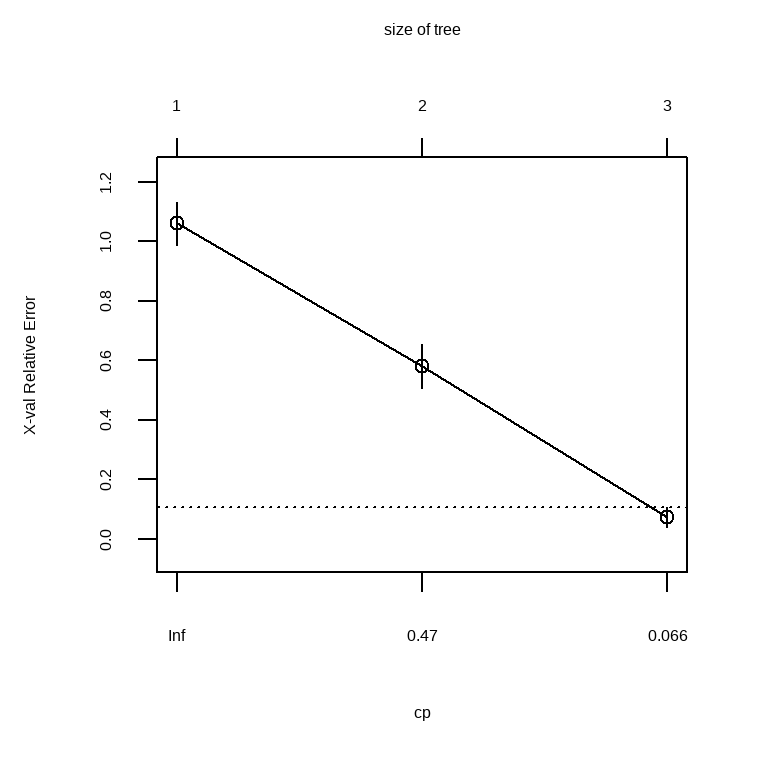

```r
plotcp(ct_model)
```

alternative we can access the table of numbers using:

```r
printcp(ct_model)
```

```
Classification tree:
rpart(formula = Species ~ ., data = trainData, method = "class")

Variables actually used in tree construction:
[1] Petal.Length Petal.Width

Root node error: 67/105 = 0.6381

n= 105

       CP nsplit rel error   xerror     xstd
1 0.50746      0  1.000000 1.059701 0.071565
2 0.43284      1  0.492537 0.582090 0.073898
3 0.01000      2  0.059701 0.074627 0.032570
```

This output helps you understand how the cross-validated error changes as the tree size increases and help discern the optimal tree size.

We can get the value programatically:

```r
# Prune the tree based on the optimal cp
optimal_cp <- ct_model$cptable[which.min(ct_model$cptable[,"xerror"]), "CP"]
optimal_cp
```

```
[1] 0.01
```

In our case, the optimal `cp` value is 0.01 which corresponds to our largest tree with 3 terminal nodes. In our case, this suggests that we don’t need to prune our tree. If we did require pruning, we could easily achieve this:

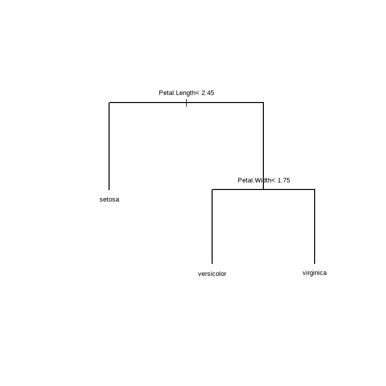

```r
pruned_model <- prune(ct_model, cp = optimal_cp)

plot(pruned_model, margin = 0.1)  # Increase the margin parameter for more space
text(pruned_model,  cex = 0.8)
```

# 4 Bagging

*Bootstrap aggregation* or *bagging* is a general-purpose procedure for reducing the variance of a statistical learning method, it is particularly useful and frequently used in the context of decision trees. Recall that given a set of n independent observations $Z_1,Z_2,\dots,Z_n$ , each with variance $\sigma^2$, the variance of the mean $\bar Z$ of the observations is given by $\sigma^2/n$. In other words, averaging a set of observations reduces variance. Of course, this is not practical because we generally do not have access to multiple training sets. Instead, we can bootstrap, by taking repeated samples from the single training set. In this approach, we generate B different bootstrapped training datasets. We then train our method on the bth bootstrapped training set in order to get the prediction at point x. We then average all the predictions. For classification it works similarly. We can have 200 trees, we have two classes, we make a prediction of each x, and for example 150 trees says class 1 and 50 says class 2, then our prediction will be class 1, so we adjust by majority vote.

**Out-of-bag** Error estimation. It turns out that there is a very straightforward way to estimate the **test error** of a bagged model. Recall that the key to bagging is that trees are repeatedly fit to bootstrapped subsets of observations. One can show that on average, each bagged tree makes use of around two-thirds of the observations. The remaining one-third of the observations not used to fit a given bagged tree are referred as to the *out-of-bag (OOB)* observations. We can predict the response for the $i$th observation using each of the trees in which that observation was OOB. This will yield around B/3 predictions for the $i$th observation, which we average. We do that for each of the observations. This estimate is essentially the Leave One Out (LOO) cross-validation error for bagging, if B is large.

Bagging results in improved accuracy over prediction using single tree but it can be difficult to interpret the resulting model. We can’t represent the statistical learning procedure using a single tree. It’s not clear which variables are most important to the procedure (we have many trees each of which may give a differing view on the importance of a given predictor). So which predictors are important? An overall summary of the importance of each predictor can be achieved by recording how much the average RSS or Gini index improves or decreases when each tree is split over a given predictor (averaged over all B trees)

# 5 Random Forest

A problem with bagging is that bagged trees may be highly similar to each other. For example if there is a strong predictor in the data, most of the bagged trees will use this predictor in the top split so that the predictions of the bagged trees will be highly correlated. Averaging highly correlated quantities does not lead to as large a reduction in variance as averaging many uncorrelated quantities.

*Random forests* provide an improvement over bagged trees by way of a small tweak that decorrelates the trees. This reduces the variance when we average the trees. As in bagging, we build a number of decision trees on bootstrapped training samples, but when building these trees, each time a split in a tree is considered, a random selection of $m$ predictors is chosen as a split candidates from the full set of $p$ predictors. The split is allowed to use only one of the $m$ predictors. A fresh selection of $m$ predictors is taken at each split, and typically, we choose $m \sim \sqrt p$ that is, the number of predictors considered at each split is approximately equal to the square root of the total number of predictors. The effect of this is that it forces the tree to choose different predictors at different times, and since we are going to build lots of trees, all predictors will be considered at each split among the different trees.

Bagging and Random forest

Here we apply bagging and random forests to the `Boston` data, using the `randomForest` package in `R`. The exact results obtained in this section may depend on the version of `R` and the version of the `randomForest` package installed on your computer. Recall that bagging is simply a special case of a random forest with $m=p$. Therefore, the `randomForest()` function can be used to perform both random forests and bagging.

We perform bagging as follows:

```r
set.seed(1)
train <- sample(1:nrow(Boston), nrow(Boston) / 2)

bag.boston <- randomForest(medv ~ ., data = Boston,
    subset = train, mtry = 12, importance = TRUE)
bag.boston
```

```
Call:
 randomForest(formula = medv ~ ., data = Boston, mtry = 12, importance = TRUE,      subset = train)
               Type of random forest: regression
                     Number of trees: 500
No. of variables tried at each split: 12

          Mean of squared residuals: 11.25779
                    % Var explained: 85.35
```

The argument `mtry = 12` indicates that all $12$ predictors should be considered for each split of the tree -in other words, that bagging should be done. How well does this bagged model perform on the test set?

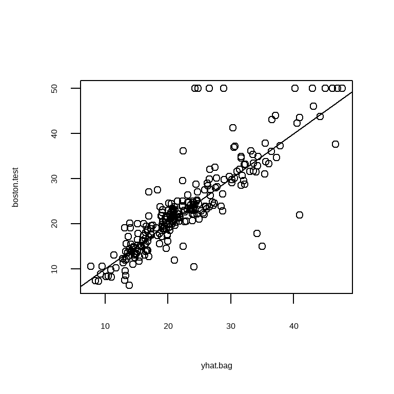

```r
yhat.bag <- predict(bag.boston, newdata = Boston[-train, ])
plot(yhat.bag, boston.test)
abline(0, 1)
```

```r
mean((yhat.bag - boston.test)^2)
```

```
[1] 23.40359
```

We could change the number of trees grown by `randomForest()` using the `ntree` argument:

```r
bag.boston <- randomForest(medv ~ ., data = Boston,
    subset = train, mtry = 12, ntree = 25)
yhat.bag <- predict(bag.boston, newdata = Boston[-train, ])

boston.test <- Boston[-train, "medv"]
mean((yhat.bag - boston.test)^2)
```

```
[1] 24.59162
```

**Random Forest**

Growing a random forest proceeds in exactly the same way, except that we use a smaller value of the `mtry` argument. By default, `randomForest()` uses $p/3$ variables when building a random forest of regression trees, and $\sqrt{p}$ variables when building a random forest of classification trees. Here we use `mtry = 6`.

```r
set.seed(1)
rf.boston <- randomForest(medv ~ ., data = Boston,
    subset = train, mtry = 6, importance = TRUE)

yhat.rf <- predict(rf.boston, newdata = Boston[-train, ])
rf.boston
```

```
Call:
 randomForest(formula = medv ~ ., data = Boston, mtry = 6, importance = TRUE,      subset = train)
               Type of random forest: regression
                     Number of trees: 500
No. of variables tried at each split: 6

          Mean of squared residuals: 10.09466
                    % Var explained: 86.87
```

```r
boston.test <- Boston[-train, "medv"]
mean((yhat.rf - boston.test)^2)
```

```
[1] 20.06644
```

The test set MSE is $20.07$; this indicates that random forests yielded an improvement over bagging in this case. The Mean of Squared residuals reported by the test is calculated over the Out of Bag dataset, so it is an unbiased statistic.

We are going to do a manual check to see those test errors for different number of values for the parameter `mtry` (the number of variables to be taken into consideration for each ramification in the tree building)

```r
oob.err = double(12) #out of bag error
test.err = double(12)

for(mtry in 1:12){
  fit= randomForest(medv ~., data=Boston, subset=train, mtry=mtry, ntree=400)
  oob.err[mtry] = fit$mse[400]
  pred= predict(fit,Boston[-train,])
  test.err[mtry] = with (Boston[-train,], mean((medv-pred)^2))
  cat(mtry," ")

}
```

```
1  2  3  4  5  6  7  8  9  10  11  12
```

[figure not shown]

```r
matplot(1:mtry,cbind(test.err,oob.err), pch=19,col=c("red","blue"), type ="b", ylab="mse")
legend("top", inset = 0.0, legend = c("OOB", "Test"), pch = 19, col = c("red", "blue"), horiz = TRUE, x.intersp = 0.5)
```

Using the `importance()` function, we can view the importance of each variable.

```r
importance(rf.boston)
```

```
          %IncMSE IncNodePurity
crim    19.435587    1070.42307
zn       3.091630      82.19257
indus    6.140529     590.09536
chas     1.370310      36.70356
nox     13.263466     859.97091
rm      35.094741    8270.33906
age     15.144821     634.31220
dis      9.163776     684.87953
rad      4.793720      83.18719
tax      4.410714     292.20949
ptratio  8.612780     902.20190
lstat   28.725343    5813.04833
```

Two measures of variable importance are reported. The first is based upon the mean decrease of accuracy in predictions on the out of bag samples when a given variable is permuted. The second is a measure of the total decrease in node impurity that results from splits over that variable, averaged over all trees. In the case of regression trees, the node impurity is measured by the training RSS, and for classification trees by the deviance. Plots of these importance measures can be produced using the `varImpPlot()` function.

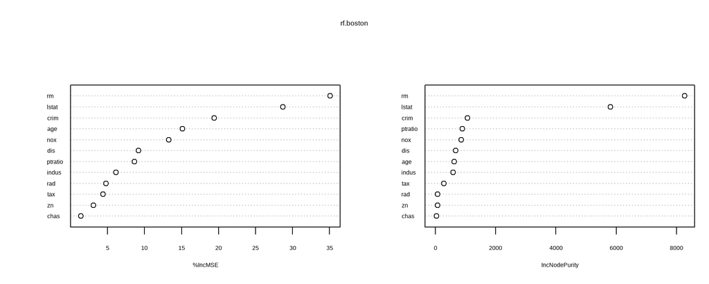

```r
varImpPlot(rf.boston)
```

The results indicate that across all of the trees considered in the random forest, the wealth of the community (`lstat`) and the house size (`rm`) are by far the two most important variables.

Classification with Random Forest

We are going to use again the Iris dataset for the classification problem

```r
rf_model<- randomForest(formula = Species ~., data= trainData, ntree=100,
  importance=TRUE)
rf_model
```

```
Call:
 randomForest(formula = Species ~ ., data = trainData, ntree = 100,      importance = TRUE)
               Type of random forest: classification
                     Number of trees: 100
No. of variables tried at each split: 2

        OOB estimate of  error rate: 4.76%
Confusion matrix:
           setosa versicolor virginica class.error
setosa         34          0         0  0.00000000
versicolor      0         31         2  0.06060606
virginica       0          3        35  0.07894737
```

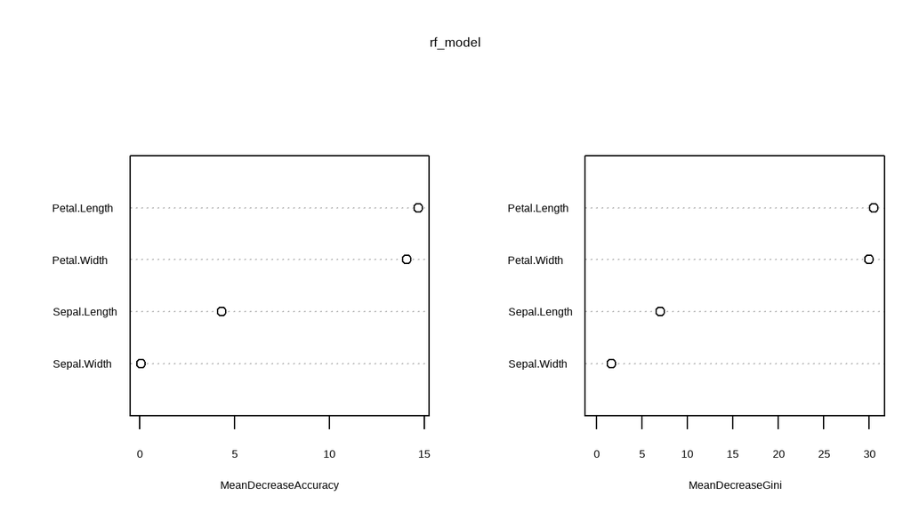

```r
# Make predictions on the test set
rf_pred <- predict(rf_model, newdata = testData)
varImpPlot(rf_model)
```

Based on this, `Petal.Width` and `Petal.Length` are the most important features for predicting the species of iris flowers. We can evaluate the performance of this model using confusion matrix:

```r
(rf_conf_mat <- caret::confusionMatrix(rf_pred, testData$Species))
```

```
Confusion Matrix and Statistics

            Reference
Prediction   setosa versicolor virginica
  setosa         16          0         0
  versicolor      0         16         0
  virginica       0          1        12

Overall Statistics

               Accuracy : 0.9778
                 95% CI : (0.8823, 0.9994)
    No Information Rate : 0.3778
    P-Value [Acc > NIR] : < 0.00000000000000022

                  Kappa : 0.9664

 Mcnemar's Test P-Value : NA

Statistics by Class:

                     Class: setosa Class: versicolor Class: virginica
Sensitivity                 1.0000            0.9412           1.0000
Specificity                 1.0000            1.0000           0.9697
Pos Pred Value              1.0000            1.0000           0.9231
Neg Pred Value              1.0000            0.9655           1.0000
Prevalence                  0.3556            0.3778           0.2667
Detection Rate              0.3556            0.3556           0.2667
Detection Prevalence        0.3556            0.3556           0.2889
Balanced Accuracy           1.0000            0.9706           0.9848
```

and the metrics by class:

```r
rf_conf_mat$byClass
```

```
                  Sensitivity Specificity Pos Pred Value Neg Pred Value
Class: setosa       1.0000000    1.000000      1.0000000      1.0000000
Class: versicolor   0.9411765    1.000000      1.0000000      0.9655172
Class: virginica    1.0000000    0.969697      0.9230769      1.0000000
                  Precision    Recall       F1 Prevalence Detection Rate
Class: setosa     1.0000000 1.0000000 1.000000  0.3555556      0.3555556
Class: versicolor 1.0000000 0.9411765 0.969697  0.3777778      0.3555556
Class: virginica  0.9230769 1.0000000 0.960000  0.2666667      0.2666667
                  Detection Prevalence Balanced Accuracy
Class: setosa                0.3555556         1.0000000
Class: versicolor            0.3555556         0.9705882
Class: virginica             0.2888889         0.9848485
```